# Risk Factor Analysis

## Outcome Variable

**Outcome Variable:** stunted

## Predictor Variables

**Intervention Variable:** tr

**Adjustment Set:**

unadjusted

## Stratifying Variables

The analysis was stratified on these variable(s):

- parity
- agecat
- studyid
- country

## Data Summary

| parity | agecat | studyid | country | tr | stunted | n_cell | n |
| --- | --- | --- | --- | --- | --- | --- | --- |
| 3+ | 24 months | ki1000110-WASH-Bangladesh | BANGLADESH | Control | 0 | 42 | 400 |
| 3+ | 24 months | ki1000110-WASH-Bangladesh | BANGLADESH | Control | 1 | 37 | 400 |
| 3+ | 24 months | ki1000110-WASH-Bangladesh | BANGLADESH | LNS | 0 | 61 | 400 |
| 3+ | 24 months | ki1000110-WASH-Bangladesh | BANGLADESH | LNS | 1 | 54 | 400 |
| 3+ | 24 months | ki1000110-WASH-Bangladesh | BANGLADESH | Other | 0 | 111 | 400 |
| 3+ | 24 months | ki1000110-WASH-Bangladesh | BANGLADESH | Other | 1 | 95 | 400 |
| 1 | 24 months | ki1000110-WASH-Bangladesh | BANGLADESH | Control | 0 | 62 | 411 |
| 1 | 24 months | ki1000110-WASH-Bangladesh | BANGLADESH | Control | 1 | 42 | 411 |
| 1 | 24 months | ki1000110-WASH-Bangladesh | BANGLADESH | LNS | 0 | 62 | 411 |
| 1 | 24 months | ki1000110-WASH-Bangladesh | BANGLADESH | LNS | 1 | 31 | 411 |
| 1 | 24 months | ki1000110-WASH-Bangladesh | BANGLADESH | Other | 0 | 130 | 411 |
| 1 | 24 months | ki1000110-WASH-Bangladesh | BANGLADESH | Other | 1 | 84 | 411 |
| 2 | 24 months | ki1000110-WASH-Bangladesh | BANGLADESH | Control | 0 | 52 | 376 |
| 2 | 24 months | ki1000110-WASH-Bangladesh | BANGLADESH | Control | 1 | 36 | 376 |
| 2 | 24 months | ki1000110-WASH-Bangladesh | BANGLADESH | LNS | 0 | 68 | 376 |
| 2 | 24 months | ki1000110-WASH-Bangladesh | BANGLADESH | LNS | 1 | 31 | 376 |
| 2 | 24 months | ki1000110-WASH-Bangladesh | BANGLADESH | Other | 0 | 116 | 376 |
| 2 | 24 months | ki1000110-WASH-Bangladesh | BANGLADESH | Other | 1 | 73 | 376 |
| 1 | 6 months | ki1000110-WASH-Bangladesh | BANGLADESH | Control | 0 | 40 | 231 |
| 1 | 6 months | ki1000110-WASH-Bangladesh | BANGLADESH | Control | 1 | 9 | 231 |
| 1 | 6 months | ki1000110-WASH-Bangladesh | BANGLADESH | LNS | 0 | 57 | 231 |
| 1 | 6 months | ki1000110-WASH-Bangladesh | BANGLADESH | LNS | 1 | 15 | 231 |
| 1 | 6 months | ki1000110-WASH-Bangladesh | BANGLADESH | Other | 0 | 91 | 231 |
| 1 | 6 months | ki1000110-WASH-Bangladesh | BANGLADESH | Other | 1 | 19 | 231 |
| 2 | 6 months | ki1000110-WASH-Bangladesh | BANGLADESH | Control | 0 | 37 | 195 |
| 2 | 6 months | ki1000110-WASH-Bangladesh | BANGLADESH | Control | 1 | 13 | 195 |
| 2 | 6 months | ki1000110-WASH-Bangladesh | BANGLADESH | LNS | 0 | 42 | 195 |
| 2 | 6 months | ki1000110-WASH-Bangladesh | BANGLADESH | LNS | 1 | 6 | 195 |
| 2 | 6 months | ki1000110-WASH-Bangladesh | BANGLADESH | Other | 0 | 91 | 195 |
| 2 | 6 months | ki1000110-WASH-Bangladesh | BANGLADESH | Other | 1 | 6 | 195 |

[output cut: 249 more lines]

The following strata were considered:

- parity: 1, agecat: 24 months, studyid: iLiNS_DYADM_LNS, country: MALAWI
- parity: 1, agecat: 24 months, studyid: ki1000110-WASH-Bangladesh, country: BANGLADESH
- parity: 1, agecat: 24 months, studyid: ki1017093b-PROVIDE, country: BANGLADESH
- parity: 1, agecat: 24 months, studyid: ki1066203-TanzaniaChild2, country: TANZANIA, UNITED REPUBLIC OF
- parity: 1, agecat: 24 months, studyid: ki1112895-Burkina Faso Zn, country: BURKINA FASO
- parity: 1, agecat: 24 months, studyid: ki1126311-ZVITAMBO, country: ZIMBABWE
- parity: 1, agecat: 24 months, studyid: ki1135781-COHORTS, country: GUATEMALA
- parity: 1, agecat: 24 months, studyid: ki1148112-iLiNS-DYAD-M, country: MALAWI
- parity: 1, agecat: 24 months, studyid: kiGH5241-JiVitA-3, country: BANGLADESH
- parity: 1, agecat: 6 months, studyid: iLiNS_DYADM_LNS, country: MALAWI
- parity: 1, agecat: 6 months, studyid: ki1000110-WASH-Bangladesh, country: BANGLADESH
- parity: 1, agecat: 6 months, studyid: ki1000304b-SAS-CompFeed, country: INDIA
- parity: 1, agecat: 6 months, studyid: ki1000304b-SAS-FoodSuppl, country: INDIA
- parity: 1, agecat: 6 months, studyid: ki1017093b-PROVIDE, country: BANGLADESH
- parity: 1, agecat: 6 months, studyid: ki1066203-TanzaniaChild2, country: TANZANIA, UNITED REPUBLIC OF
- parity: 1, agecat: 6 months, studyid: ki1112895-Burkina Faso Zn, country: BURKINA FASO
- parity: 1, agecat: 6 months, studyid: ki1126311-ZVITAMBO, country: ZIMBABWE
- parity: 1, agecat: 6 months, studyid: ki1135781-COHORTS, country: GUATEMALA
- parity: 1, agecat: 6 months, studyid: ki1148112-iLiNS-DYAD-M, country: MALAWI
- parity: 1, agecat: 6 months, studyid: kiGH5241-JiVitA-3, country: BANGLADESH
- parity: 1, agecat: Birth, studyid: iLiNS_DYADM_LNS, country: MALAWI
- parity: 1, agecat: Birth, studyid: ki1000304b-SAS-CompFeed, country: INDIA
- parity: 1, agecat: Birth, studyid: ki1126311-ZVITAMBO, country: ZIMBABWE
- parity: 1, agecat: Birth, studyid: ki1135781-COHORTS, country: GUATEMALA
- parity: 1, agecat: Birth, studyid: ki1148112-iLiNS-DYAD-M, country: MALAWI
- parity: 1, agecat: Birth, studyid: kiGH5241-JiVitA-3, country: BANGLADESH
- parity: 2, agecat: 24 months, studyid: iLiNS_DYADM_LNS, country: MALAWI
- parity: 2, agecat: 24 months, studyid: ki1000110-WASH-Bangladesh, country: BANGLADESH
- parity: 2, agecat: 24 months, studyid: ki1017093b-PROVIDE, country: BANGLADESH
- parity: 2, agecat: 24 months, studyid: ki1112895-Burkina Faso Zn, country: BURKINA FASO
- parity: 2, agecat: 24 months, studyid: ki1126311-ZVITAMBO, country: ZIMBABWE
- parity: 2, agecat: 24 months, studyid: ki1135781-COHORTS, country: GUATEMALA
- parity: 2, agecat: 24 months, studyid: ki1148112-iLiNS-DYAD-M, country: MALAWI
- parity: 2, agecat: 24 months, studyid: kiGH5241-JiVitA-3, country: BANGLADESH
- parity: 2, agecat: 6 months, studyid: iLiNS_DYADM_LNS, country: MALAWI
- parity: 2, agecat: 6 months, studyid: ki1000110-WASH-Bangladesh, country: BANGLADESH
- parity: 2, agecat: 6 months, studyid: ki1000304b-SAS-CompFeed, country: INDIA
- parity: 2, agecat: 6 months, studyid: ki1000304b-SAS-FoodSuppl, country: INDIA
- parity: 2, agecat: 6 months, studyid: ki1017093b-PROVIDE, country: BANGLADESH
- parity: 2, agecat: 6 months, studyid: ki1066203-TanzaniaChild2, country: TANZANIA, UNITED REPUBLIC OF
- parity: 2, agecat: 6 months, studyid: ki1112895-Burkina Faso Zn, country: BURKINA FASO
- parity: 2, agecat: 6 months, studyid: ki1126311-ZVITAMBO, country: ZIMBABWE
- parity: 2, agecat: 6 months, studyid: ki1135781-COHORTS, country: GUATEMALA
- parity: 2, agecat: 6 months, studyid: ki1148112-iLiNS-DYAD-M, country: MALAWI
- parity: 2, agecat: 6 months, studyid: kiGH5241-JiVitA-3, country: BANGLADESH
- parity: 2, agecat: Birth, studyid: ki1000304b-SAS-CompFeed, country: INDIA
- parity: 2, agecat: Birth, studyid: ki1126311-ZVITAMBO, country: ZIMBABWE
- parity: 2, agecat: Birth, studyid: ki1135781-COHORTS, country: GUATEMALA
- parity: 2, agecat: Birth, studyid: kiGH5241-JiVitA-3, country: BANGLADESH
- parity: 3+, agecat: 24 months, studyid: iLiNS_DYADM_LNS, country: MALAWI
- parity: 3+, agecat: 24 months, studyid: ki1000110-WASH-Bangladesh, country: BANGLADESH
- parity: 3+, agecat: 24 months, studyid: ki1066203-TanzaniaChild2, country: TANZANIA, UNITED REPUBLIC OF
- parity: 3+, agecat: 24 months, studyid: ki1112895-Burkina Faso Zn, country: BURKINA FASO
- parity: 3+, agecat: 24 months, studyid: ki1126311-ZVITAMBO, country: ZIMBABWE
- parity: 3+, agecat: 24 months, studyid: ki1135781-COHORTS, country: GUATEMALA
- parity: 3+, agecat: 24 months, studyid: ki1148112-iLiNS-DYAD-M, country: MALAWI
- parity: 3+, agecat: 24 months, studyid: kiGH5241-JiVitA-3, country: BANGLADESH
- parity: 3+, agecat: 6 months, studyid: iLiNS_DYADM_LNS, country: MALAWI
- parity: 3+, agecat: 6 months, studyid: ki1000110-WASH-Bangladesh, country: BANGLADESH
- parity: 3+, agecat: 6 months, studyid: ki1000304b-SAS-CompFeed, country: INDIA
- parity: 3+, agecat: 6 months, studyid: ki1000304b-SAS-FoodSuppl, country: INDIA
- parity: 3+, agecat: 6 months, studyid: ki1017093b-PROVIDE, country: BANGLADESH
- parity: 3+, agecat: 6 months, studyid: ki1066203-TanzaniaChild2, country: TANZANIA, UNITED REPUBLIC OF
- parity: 3+, agecat: 6 months, studyid: ki1112895-Burkina Faso Zn, country: BURKINA FASO
- parity: 3+, agecat: 6 months, studyid: ki1126311-ZVITAMBO, country: ZIMBABWE
- parity: 3+, agecat: 6 months, studyid: ki1135781-COHORTS, country: GUATEMALA
- parity: 3+, agecat: 6 months, studyid: ki1148112-iLiNS-DYAD-M, country: MALAWI
- parity: 3+, agecat: 6 months, studyid: kiGH5241-JiVitA-3, country: BANGLADESH
- parity: 3+, agecat: Birth, studyid: ki1000304b-SAS-CompFeed, country: INDIA
- parity: 3+, agecat: Birth, studyid: ki1126311-ZVITAMBO, country: ZIMBABWE
- parity: 3+, agecat: Birth, studyid: ki1135781-COHORTS, country: GUATEMALA
- parity: 3+, agecat: Birth, studyid: kiGH5241-JiVitA-3, country: BANGLADESH

### Dropped Strata

Some strata were dropped due to rare outcomes:

- parity: 2, agecat: Birth, studyid: ki1000304b-SAS-CompFeed, country: INDIA
- parity: 2, agecat: 6 months, studyid: ki1017093b-PROVIDE, country: BANGLADESH
- parity: 1, agecat: 6 months, studyid: ki1017093b-PROVIDE, country: BANGLADESH
- parity: 3+, agecat: 6 months, studyid: ki1017093b-PROVIDE, country: BANGLADESH
- parity: 1, agecat: 24 months, studyid: ki1017093b-PROVIDE, country: BANGLADESH
- parity: 2, agecat: 24 months, studyid: ki1017093b-PROVIDE, country: BANGLADESH
- parity: 3+, agecat: 24 months, studyid: ki1066203-TanzaniaChild2, country: TANZANIA, UNITED REPUBLIC OF
- parity: 1, agecat: 24 months, studyid: ki1066203-TanzaniaChild2, country: TANZANIA, UNITED REPUBLIC OF
- parity: 2, agecat: 24 months, studyid: ki1126311-ZVITAMBO, country: ZIMBABWE
- parity: 1, agecat: 24 months, studyid: ki1126311-ZVITAMBO, country: ZIMBABWE
- parity: 3+, agecat: 24 months, studyid: ki1126311-ZVITAMBO, country: ZIMBABWE
- parity: 1, agecat: 24 months, studyid: ki1135781-COHORTS, country: GUATEMALA
- parity: 2, agecat: Birth, studyid: ki1135781-COHORTS, country: GUATEMALA
- parity: 2, agecat: 24 months, studyid: ki1135781-COHORTS, country: GUATEMALA
- parity: 1, agecat: Birth, studyid: ki1135781-COHORTS, country: GUATEMALA
- parity: 1, agecat: Birth, studyid: ki1148112-iLiNS-DYAD-M, country: MALAWI
- parity: 1, agecat: 24 months, studyid: ki1148112-iLiNS-DYAD-M, country: MALAWI
- parity: 3+, agecat: 24 months, studyid: ki1148112-iLiNS-DYAD-M, country: MALAWI
- parity: 2, agecat: 24 months, studyid: ki1148112-iLiNS-DYAD-M, country: MALAWI
- parity: 2, agecat: 24 months, studyid: kiGH5241-JiVitA-3, country: BANGLADESH
- parity: 3+, agecat: 24 months, studyid: kiGH5241-JiVitA-3, country: BANGLADESH
- parity: 1, agecat: Birth, studyid: iLiNS_DYADM_LNS, country: MALAWI
- parity: 1, agecat: 24 months, studyid: iLiNS_DYADM_LNS, country: MALAWI
- parity: 3+, agecat: 24 months, studyid: iLiNS_DYADM_LNS, country: MALAWI
- parity: 2, agecat: 24 months, studyid: iLiNS_DYADM_LNS, country: MALAWI

## Methods Detail

We’re interested in the causal parameters $E[Y_a]$ for all values of $a \in \mathcal{A}$. These parameters represent the mean outcome if, possibly contrary to fact, we intervened to set all units to have $A=a$. Under the randomization and positivity assumptions, these are identified by the statistical parameters $\psi_a=E_W[E_{Y|A,W}(Y|A=a,W)]$. In addition, we’re interested in the mean of $Y$, $E[Y]$ under no intervention (the observed mean). We will estimate these parameters by using SuperLearner to fit the relevant likelihood factors – $E_{Y|A,W}(Y|A=a,W)$ and $p(A=a|W)$, and then updating our likelihood fit using a joint TMLE.

For unadjusted analyses ($W=\{\}$), initial likelihoods were estimated using Lrnr_glm to estimate the simple $E(Y|A)$ and Lrnr_mean to estimate $p(A)$. For adjusted analyses, a small library containing Lrnr_glmnet, Lrnr_xgboost, and Lrnr_mean was used.

Having estimated these parameters, we will then use the delta method to estimate relative risks and attributable risks relative to a prespecified baseline level of $A$.

[output not shown]

# Results Detail

## Results Plots

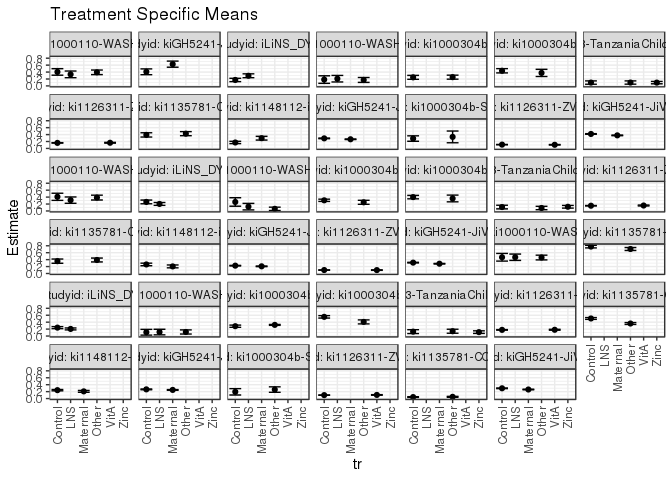

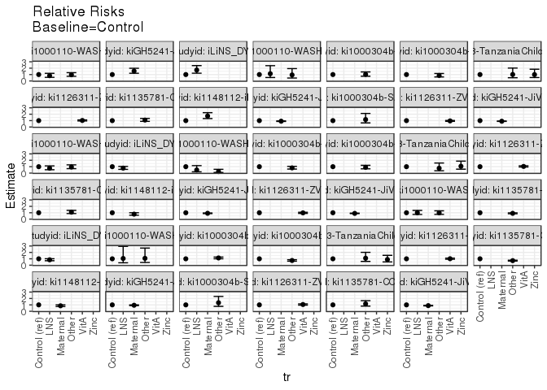

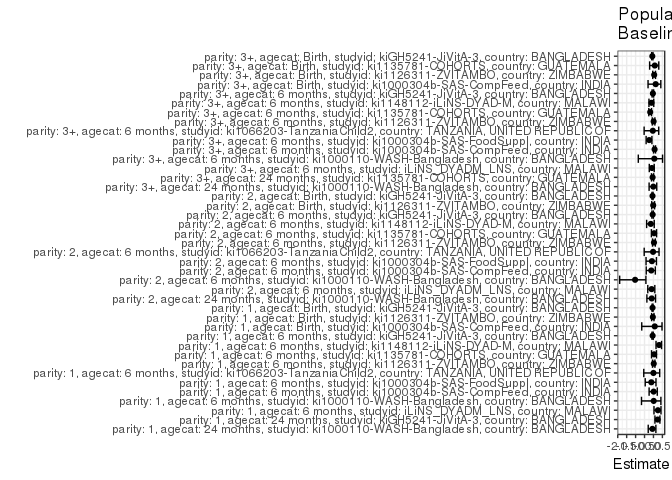

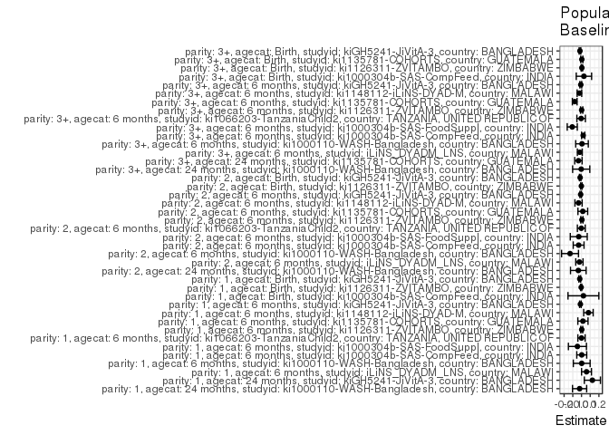

## Results Table

### Parameter: TSM

| parity | agecat | studyid | country | intervention_level | baseline_level | estimate | ci_lower | ci_upper |
| --- | --- | --- | --- | --- | --- | --- | --- | --- |
| 1 | Birth | ki1000304b-SAS-CompFeed | INDIA | Control | NA | 0.2857143 | 0.2070526 | 0.3643760 |
| 1 | Birth | ki1000304b-SAS-CompFeed | INDIA | Other | NA | 0.3333333 | 0.1637234 | 0.5029433 |
| 1 | Birth | ki1126311-ZVITAMBO | ZIMBABWE | Control | NA | 0.1108844 | 0.1069331 | 0.1148356 |
| 1 | Birth | ki1126311-ZVITAMBO | ZIMBABWE | VitA | NA | 0.1059529 | 0.0991749 | 0.1127309 |
| 1 | Birth | kiGH5241-JiVitA-3 | BANGLADESH | Control | NA | 0.4177296 | 0.4084400 | 0.4270192 |
| 1 | Birth | kiGH5241-JiVitA-3 | BANGLADESH | Maternal | NA | 0.3776715 | 0.3680100 | 0.3873329 |
| 1 | 6 months | iLiNS_DYADM_LNS | MALAWI | Control | NA | 0.1718750 | 0.1231872 | 0.2205628 |
| 1 | 6 months | iLiNS_DYADM_LNS | MALAWI | LNS | NA | 0.2931034 | 0.2371821 | 0.3490248 |
| 1 | 6 months | ki1000110-WASH-Bangladesh | BANGLADESH | Control | NA | 0.1836735 | 0.0750191 | 0.2923279 |
| 1 | 6 months | ki1000110-WASH-Bangladesh | BANGLADESH | LNS | NA | 0.2083333 | 0.1143232 | 0.3023434 |
| 1 | 6 months | ki1000110-WASH-Bangladesh | BANGLADESH | Other | NA | 0.1727273 | 0.1019329 | 0.2435216 |
| 1 | 6 months | ki1000304b-SAS-CompFeed | INDIA | Control | NA | 0.2471910 | 0.1906328 | 0.3037492 |
| 1 | 6 months | ki1000304b-SAS-CompFeed | INDIA | Other | NA | 0.2527473 | 0.1956560 | 0.3098385 |
| 1 | 6 months | ki1000304b-SAS-FoodSuppl | INDIA | Control | NA | 0.4375000 | 0.3762511 | 0.4987489 |
| 1 | 6 months | ki1000304b-SAS-FoodSuppl | INDIA | Other | NA | 0.3750000 | 0.2714705 | 0.4785295 |
| 1 | 6 months | ki1066203-TanzaniaChild2 | TANZANIA, UNITED REPUBLIC OF | Control | NA | 0.0965517 | 0.0484379 | 0.1446655 |
| 1 | 6 months | ki1066203-TanzaniaChild2 | TANZANIA, UNITED REPUBLIC OF | Other | NA | 0.0974026 | 0.0505327 | 0.1442725 |
| 1 | 6 months | ki1066203-TanzaniaChild2 | TANZANIA, UNITED REPUBLIC OF | Zinc | NA | 0.0957447 | 0.0613730 | 0.1301163 |
| 1 | 6 months | ki1126311-ZVITAMBO | ZIMBABWE | Control | NA | 0.1603774 | 0.1540463 | 0.1667084 |
| 1 | 6 months | ki1126311-ZVITAMBO | ZIMBABWE | VitA | NA | 0.1640459 | 0.1526685 | 0.1754233 |
| 1 | 6 months | ki1135781-COHORTS | GUATEMALA | Control | NA | 0.3913043 | 0.3299474 | 0.4526613 |
| 1 | 6 months | ki1135781-COHORTS | GUATEMALA | Other | NA | 0.4262295 | 0.3677724 | 0.4846866 |
| 1 | 6 months | ki1148112-iLiNS-DYAD-M | MALAWI | Control | NA | 0.1718750 | 0.1387347 | 0.2050153 |
| 1 | 6 months | ki1148112-iLiNS-DYAD-M | MALAWI | Maternal | NA | 0.2956522 | 0.2419187 | 0.3493856 |
| 1 | 6 months | kiGH5241-JiVitA-3 | BANGLADESH | Control | NA | 0.2910168 | 0.2815378 | 0.3004959 |
| 1 | 6 months | kiGH5241-JiVitA-3 | BANGLADESH | Maternal | NA | 0.2649762 | 0.2560544 | 0.2738980 |
| 1 | 24 months | ki1000110-WASH-Bangladesh | BANGLADESH | Control | NA | 0.4038462 | 0.3094297 | 0.4982626 |
| 1 | 24 months | ki1000110-WASH-Bangladesh | BANGLADESH | LNS | NA | 0.3333333 | 0.2374089 | 0.4292578 |
| 1 | 24 months | ki1000110-WASH-Bangladesh | BANGLADESH | Other | NA | 0.3925234 | 0.3270194 | 0.4580274 |
| 1 | 24 months | kiGH5241-JiVitA-3 | BANGLADESH | Control | NA | 0.4074074 | 0.3233026 | 0.4915122 |

[output cut: 61 more lines]

### Parameter: E(Y)

| parity | agecat | studyid | country | intervention_level | baseline_level | estimate | ci_lower | ci_upper |
| --- | --- | --- | --- | --- | --- | --- | --- | --- |
| 1 | Birth | ki1000304b-SAS-CompFeed | INDIA | NA | NA | 0.3076923 | 0.1203158 | 0.4950688 |
| 1 | Birth | ki1126311-ZVITAMBO | ZIMBABWE | NA | NA | 0.1071668 | 0.0993209 | 0.1150126 |
| 1 | Birth | kiGH5241-JiVitA-3 | BANGLADESH | NA | NA | 0.3977037 | 0.3842293 | 0.4111782 |
| 1 | 6 months | iLiNS_DYADM_LNS | MALAWI | NA | NA | 0.2295082 | 0.1545812 | 0.3044352 |
| 1 | 6 months | ki1000110-WASH-Bangladesh | BANGLADESH | NA | NA | 0.1861472 | 0.1358452 | 0.2364492 |
| 1 | 6 months | ki1000304b-SAS-CompFeed | INDIA | NA | NA | 0.2500000 | 0.1695680 | 0.3304320 |
| 1 | 6 months | ki1000304b-SAS-FoodSuppl | INDIA | NA | NA | 0.3906250 | 0.2701491 | 0.5111009 |
| 1 | 6 months | ki1066203-TanzaniaChild2 | TANZANIA, UNITED REPUBLIC OF | NA | NA | 0.0963855 | 0.0723678 | 0.1204033 |
| 1 | 6 months | ki1126311-ZVITAMBO | ZIMBABWE | NA | NA | 0.1631664 | 0.1501460 | 0.1761868 |
| 1 | 6 months | ki1135781-COHORTS | GUATEMALA | NA | NA | 0.4076923 | 0.3228928 | 0.4924918 |
| 1 | 6 months | ki1148112-iLiNS-DYAD-M | MALAWI | NA | NA | 0.2513966 | 0.1876667 | 0.3151266 |
| 1 | 6 months | kiGH5241-JiVitA-3 | BANGLADESH | NA | NA | 0.2781009 | 0.2650483 | 0.2911536 |
| 1 | 24 months | ki1000110-WASH-Bangladesh | BANGLADESH | NA | NA | 0.3819951 | 0.3349645 | 0.4290258 |
| 1 | 24 months | kiGH5241-JiVitA-3 | BANGLADESH | NA | NA | 0.5322581 | 0.4071084 | 0.6574078 |
| 2 | Birth | ki1126311-ZVITAMBO | ZIMBABWE | NA | NA | 0.0986667 | 0.0895651 | 0.1077682 |
| 2 | Birth | kiGH5241-JiVitA-3 | BANGLADESH | NA | NA | 0.2979136 | 0.2853406 | 0.3104865 |
| 2 | 6 months | iLiNS_DYADM_LNS | MALAWI | NA | NA | 0.2368421 | 0.1690317 | 0.3046525 |
| 2 | 6 months | ki1000110-WASH-Bangladesh | BANGLADESH | NA | NA | 0.1282051 | 0.0811608 | 0.1752494 |
| 2 | 6 months | ki1000304b-SAS-CompFeed | INDIA | NA | NA | 0.2745098 | 0.2062724 | 0.3427472 |
| 2 | 6 months | ki1000304b-SAS-FoodSuppl | INDIA | NA | NA | 0.3684211 | 0.2592510 | 0.4775911 |
| 2 | 6 months | ki1066203-TanzaniaChild2 | TANZANIA, UNITED REPUBLIC OF | NA | NA | 0.1111111 | 0.0847987 | 0.1374235 |
| 2 | 6 months | ki1126311-ZVITAMBO | ZIMBABWE | NA | NA | 0.1561307 | 0.1414738 | 0.1707876 |
| 2 | 6 months | ki1135781-COHORTS | GUATEMALA | NA | NA | 0.3712121 | 0.2884797 | 0.4539445 |
| 2 | 6 months | ki1148112-iLiNS-DYAD-M | MALAWI | NA | NA | 0.2272727 | 0.1717702 | 0.2827753 |
| 2 | 6 months | kiGH5241-JiVitA-3 | BANGLADESH | NA | NA | 0.2169098 | 0.2047948 | 0.2290249 |
| 2 | 24 months | ki1000110-WASH-Bangladesh | BANGLADESH | NA | NA | 0.3723404 | 0.3234116 | 0.4212692 |
| 3+ | Birth | ki1000304b-SAS-CompFeed | INDIA | NA | NA | 0.2222222 | 0.0905686 | 0.3538758 |
| 3+ | Birth | ki1126311-ZVITAMBO | ZIMBABWE | NA | NA | 0.1031618 | 0.0934018 | 0.1129219 |
| 3+ | Birth | ki1135781-COHORTS | GUATEMALA | NA | NA | 0.0464345 | 0.0296254 | 0.0632436 |
| 3+ | Birth | kiGH5241-JiVitA-3 | BANGLADESH | NA | NA | 0.2783910 | 0.2653337 | 0.2914484 |
| 3+ | 6 months | iLiNS_DYADM_LNS | MALAWI | NA | NA | 0.2230392 | 0.1825964 | 0.2634820 |
| 3+ | 6 months | ki1000110-WASH-Bangladesh | BANGLADESH | NA | NA | 0.1145374 | 0.0730179 | 0.1560570 |
| 3+ | 6 months | ki1000304b-SAS-CompFeed | INDIA | NA | NA | 0.3028169 | 0.2655366 | 0.3400972 |
| 3+ | 6 months | ki1000304b-SAS-FoodSuppl | INDIA | NA | NA | 0.4471154 | 0.3793840 | 0.5148468 |
| 3+ | 6 months | ki1066203-TanzaniaChild2 | TANZANIA, UNITED REPUBLIC OF | NA | NA | 0.1225225 | 0.0952190 | 0.1498261 |
| 3+ | 6 months | ki1126311-ZVITAMBO | ZIMBABWE | NA | NA | 0.1795093 | 0.1638995 | 0.1951191 |
| 3+ | 6 months | ki1135781-COHORTS | GUATEMALA | NA | NA | 0.4283582 | 0.3908609 | 0.4658556 |
| 3+ | 6 months | ki1148112-iLiNS-DYAD-M | MALAWI | NA | NA | 0.2185008 | 0.1861301 | 0.2508715 |
| 3+ | 6 months | kiGH5241-JiVitA-3 | BANGLADESH | NA | NA | 0.2569061 | 0.2414457 | 0.2723665 |
| 3+ | 24 months | ki1000110-WASH-Bangladesh | BANGLADESH | NA | NA | 0.4650000 | 0.4160599 | 0.5139401 |
| 3+ | 24 months | ki1135781-COHORTS | GUATEMALA | NA | NA | 0.7412281 | 0.6842550 | 0.7982011 |

### Parameter: RR

| parity | agecat | studyid | country | intervention_level | baseline_level | estimate | ci_lower | ci_upper |
| --- | --- | --- | --- | --- | --- | --- | --- | --- |
| 1 | Birth | ki1000304b-SAS-CompFeed | INDIA | Control | Control | 1.0000000 | 1.0000000 | 1.0000000 |
| 1 | Birth | ki1000304b-SAS-CompFeed | INDIA | Other | Control | 1.1666667 | 0.6426354 | 2.1180144 |
| 1 | Birth | ki1126311-ZVITAMBO | ZIMBABWE | Control | Control | 1.0000000 | 1.0000000 | 1.0000000 |
| 1 | Birth | ki1126311-ZVITAMBO | ZIMBABWE | VitA | Control | 0.9555262 | 0.8880561 | 1.0281224 |
| 1 | Birth | kiGH5241-JiVitA-3 | BANGLADESH | Control | Control | 1.0000000 | 1.0000000 | 1.0000000 |
| 1 | Birth | kiGH5241-JiVitA-3 | BANGLADESH | Maternal | Control | 0.9041051 | 0.8739552 | 0.9352951 |
| 1 | 6 months | iLiNS_DYADM_LNS | MALAWI | Control | Control | 1.0000000 | 1.0000000 | 1.0000000 |
| 1 | 6 months | iLiNS_DYADM_LNS | MALAWI | LNS | Control | 1.7053292 | 1.2119424 | 2.3995757 |
| 1 | 6 months | ki1000110-WASH-Bangladesh | BANGLADESH | Control | Control | 1.0000000 | 1.0000000 | 1.0000000 |
| 1 | 6 months | ki1000110-WASH-Bangladesh | BANGLADESH | LNS | Control | 1.1342593 | 0.5389976 | 2.3869199 |
| 1 | 6 months | ki1000110-WASH-Bangladesh | BANGLADESH | Other | Control | 0.9404040 | 0.4578921 | 1.9313713 |
| 1 | 6 months | ki1000304b-SAS-CompFeed | INDIA | Control | Control | 1.0000000 | 1.0000000 | 1.0000000 |
| 1 | 6 months | ki1000304b-SAS-CompFeed | INDIA | Other | Control | 1.0224775 | 0.7412994 | 1.4103078 |
| 1 | 6 months | ki1000304b-SAS-FoodSuppl | INDIA | Control | Control | 1.0000000 | 1.0000000 | 1.0000000 |
| 1 | 6 months | ki1000304b-SAS-FoodSuppl | INDIA | Other | Control | 0.8571429 | 0.6289543 | 1.1681196 |
| 1 | 6 months | ki1066203-TanzaniaChild2 | TANZANIA, UNITED REPUBLIC OF | Control | Control | 1.0000000 | 1.0000000 | 1.0000000 |
| 1 | 6 months | ki1066203-TanzaniaChild2 | TANZANIA, UNITED REPUBLIC OF | Other | Control | 1.0088126 | 0.5046164 | 2.0167850 |
| 1 | 6 months | ki1066203-TanzaniaChild2 | TANZANIA, UNITED REPUBLIC OF | Zinc | Control | 0.9916413 | 0.5365690 | 1.8326676 |
| 1 | 6 months | ki1126311-ZVITAMBO | ZIMBABWE | Control | Control | 1.0000000 | 1.0000000 | 1.0000000 |
| 1 | 6 months | ki1126311-ZVITAMBO | ZIMBABWE | VitA | Control | 1.0228744 | 0.9444186 | 1.1078478 |
| 1 | 6 months | ki1135781-COHORTS | GUATEMALA | Control | Control | 1.0000000 | 1.0000000 | 1.0000000 |
| 1 | 6 months | ki1135781-COHORTS | GUATEMALA | Other | Control | 1.0892532 | 0.8844176 | 1.3415298 |
| 1 | 6 months | ki1148112-iLiNS-DYAD-M | MALAWI | Control | Control | 1.0000000 | 1.0000000 | 1.0000000 |
| 1 | 6 months | ki1148112-iLiNS-DYAD-M | MALAWI | Maternal | Control | 1.7201581 | 1.3197543 | 2.2420415 |
| 1 | 6 months | kiGH5241-JiVitA-3 | BANGLADESH | Control | Control | 1.0000000 | 1.0000000 | 1.0000000 |
| 1 | 6 months | kiGH5241-JiVitA-3 | BANGLADESH | Maternal | Control | 0.9105185 | 0.8688472 | 0.9541885 |
| 1 | 24 months | ki1000110-WASH-Bangladesh | BANGLADESH | Control | Control | 1.0000000 | 1.0000000 | 1.0000000 |
| 1 | 24 months | ki1000110-WASH-Bangladesh | BANGLADESH | LNS | Control | 0.8253968 | 0.5696893 | 1.1958797 |
| 1 | 24 months | ki1000110-WASH-Bangladesh | BANGLADESH | Other | Control | 0.9719626 | 0.7292930 | 1.2953797 |
| 1 | 24 months | kiGH5241-JiVitA-3 | BANGLADESH | Control | Control | 1.0000000 | 1.0000000 | 1.0000000 |

[output cut: 61 more lines]

### Parameter: PAR

| parity | agecat | studyid | country | intervention_level | baseline_level | estimate | ci_lower | ci_upper |
| --- | --- | --- | --- | --- | --- | --- | --- | --- |
| 1 | Birth | ki1000304b-SAS-CompFeed | INDIA | Control | NA | 0.0219780 | -0.1553291 | 0.1992851 |
| 1 | Birth | ki1126311-ZVITAMBO | ZIMBABWE | Control | NA | -0.0037176 | -0.0104958 | 0.0030607 |
| 1 | Birth | kiGH5241-JiVitA-3 | BANGLADESH | Control | NA | -0.0200259 | -0.0298639 | -0.0101878 |
| 1 | 6 months | iLiNS_DYADM_LNS | MALAWI | Control | NA | 0.0576332 | 0.0006809 | 0.1145855 |
| 1 | 6 months | ki1000110-WASH-Bangladesh | BANGLADESH | Control | NA | 0.0024737 | -0.0941056 | 0.0990530 |
| 1 | 6 months | ki1000304b-SAS-CompFeed | INDIA | Control | NA | 0.0028090 | -0.0544167 | 0.0600347 |
| 1 | 6 months | ki1000304b-SAS-FoodSuppl | INDIA | Control | NA | -0.0468750 | -0.1506200 | 0.0568700 |
| 1 | 6 months | ki1066203-TanzaniaChild2 | TANZANIA, UNITED REPUBLIC OF | Control | NA | -0.0001662 | -0.0418353 | 0.0415029 |
| 1 | 6 months | ki1126311-ZVITAMBO | ZIMBABWE | Control | NA | 0.0027890 | -0.0085885 | 0.0141666 |
| 1 | 6 months | ki1135781-COHORTS | GUATEMALA | Control | NA | 0.0163880 | -0.0421465 | 0.0749224 |
| 1 | 6 months | ki1148112-iLiNS-DYAD-M | MALAWI | Control | NA | 0.0795216 | 0.0250861 | 0.1339572 |
| 1 | 6 months | kiGH5241-JiVitA-3 | BANGLADESH | Control | NA | -0.0129159 | -0.0218885 | -0.0039434 |
| 1 | 24 months | ki1000110-WASH-Bangladesh | BANGLADESH | Control | NA | -0.0218510 | -0.1031830 | 0.0594809 |
| 1 | 24 months | kiGH5241-JiVitA-3 | BANGLADESH | Control | NA | 0.1248507 | 0.0321748 | 0.2175266 |
| 2 | Birth | ki1126311-ZVITAMBO | ZIMBABWE | Control | NA | -0.0014324 | -0.0093264 | 0.0064615 |
| 2 | Birth | kiGH5241-JiVitA-3 | BANGLADESH | Control | NA | -0.0157242 | -0.0241494 | -0.0072989 |
| 2 | 6 months | iLiNS_DYADM_LNS | MALAWI | Control | NA | -0.0245215 | -0.0664128 | 0.0173697 |
| 2 | 6 months | ki1000110-WASH-Bangladesh | BANGLADESH | Control | NA | -0.1317949 | -0.2290149 | -0.0345748 |
| 2 | 6 months | ki1000304b-SAS-CompFeed | INDIA | Control | NA | -0.0331825 | -0.0952157 | 0.0288507 |
| 2 | 6 months | ki1000304b-SAS-FoodSuppl | INDIA | Control | NA | -0.0315789 | -0.1290054 | 0.0658475 |
| 2 | 6 months | ki1066203-TanzaniaChild2 | TANZANIA, UNITED REPUBLIC OF | Control | NA | -0.0023641 | -0.0473941 | 0.0426660 |
| 2 | 6 months | ki1126311-ZVITAMBO | ZIMBABWE | Control | NA | 0.0046155 | -0.0082271 | 0.0174582 |
| 2 | 6 months | ki1135781-COHORTS | GUATEMALA | Control | NA | 0.0150477 | -0.0408618 | 0.0709573 |
| 2 | 6 months | ki1148112-iLiNS-DYAD-M | MALAWI | Control | NA | -0.0340909 | -0.0756361 | 0.0074543 |
| 2 | 6 months | kiGH5241-JiVitA-3 | BANGLADESH | Control | NA | -0.0096527 | -0.0181766 | -0.0011288 |
| 2 | 24 months | ki1000110-WASH-Bangladesh | BANGLADESH | Control | NA | -0.0367505 | -0.1263162 | 0.0528152 |
| 3+ | Birth | ki1000304b-SAS-CompFeed | INDIA | Control | NA | 0.0277778 | -0.0606103 | 0.1161658 |
| 3+ | Birth | ki1126311-ZVITAMBO | ZIMBABWE | Control | NA | 0.0041928 | -0.0042568 | 0.0126423 |
| 3+ | Birth | ki1135781-COHORTS | GUATEMALA | Control | NA | 0.0035774 | -0.0091113 | 0.0162660 |
| 3+ | Birth | kiGH5241-JiVitA-3 | BANGLADESH | Control | NA | -0.0178824 | -0.0268921 | -0.0088727 |
| 3+ | 6 months | iLiNS_DYADM_LNS | MALAWI | Control | NA | -0.0193850 | -0.0475701 | 0.0088001 |
| 3+ | 6 months | ki1000110-WASH-Bangladesh | BANGLADESH | Control | NA | 0.0054465 | -0.0669284 | 0.0778214 |
| 3+ | 6 months | ki1000304b-SAS-CompFeed | INDIA | Control | NA | 0.0191290 | 0.0010295 | 0.0372284 |
| 3+ | 6 months | ki1000304b-SAS-FoodSuppl | INDIA | Control | NA | -0.1064560 | -0.1643594 | -0.0485527 |
| 3+ | 6 months | ki1066203-TanzaniaChild2 | TANZANIA, UNITED REPUBLIC OF | Control | NA | -0.0043431 | -0.0532366 | 0.0445503 |
| 3+ | 6 months | ki1126311-ZVITAMBO | ZIMBABWE | Control | NA | 0.0016952 | -0.0117153 | 0.0151057 |
| 3+ | 6 months | ki1135781-COHORTS | GUATEMALA | Control | NA | -0.0780934 | -0.1053324 | -0.0508544 |
| 3+ | 6 months | ki1148112-iLiNS-DYAD-M | MALAWI | Control | NA | -0.0239234 | -0.0502287 | 0.0023818 |
| 3+ | 6 months | kiGH5241-JiVitA-3 | BANGLADESH | Control | NA | -0.0081754 | -0.0188182 | 0.0024674 |
| 3+ | 24 months | ki1000110-WASH-Bangladesh | BANGLADESH | Control | NA | -0.0033544 | -0.1020394 | 0.0953305 |
| 3+ | 24 months | ki1135781-COHORTS | GUATEMALA | Control | NA | -0.0355576 | -0.0780377 | 0.0069224 |

### Parameter: PAF

| parity | agecat | studyid | country | intervention_level | baseline_level | estimate | ci_lower | ci_upper |
| --- | --- | --- | --- | --- | --- | --- | --- | --- |
| 1 | Birth | ki1000304b-SAS-CompFeed | INDIA | Control | NA | 0.0714286 | -0.6557354 | 0.4792375 |
| 1 | Birth | ki1126311-ZVITAMBO | ZIMBABWE | Control | NA | -0.0346896 | -0.1022606 | 0.0287391 |
| 1 | Birth | kiGH5241-JiVitA-3 | BANGLADESH | Control | NA | -0.0503538 | -0.0766777 | -0.0246734 |
| 1 | 6 months | iLiNS_DYADM_LNS | MALAWI | Control | NA | 0.2511161 | 0.0305511 | 0.4214990 |
| 1 | 6 months | ki1000110-WASH-Bangladesh | BANGLADESH | Control | NA | 0.0132890 | -0.6693520 | 0.4167806 |
| 1 | 6 months | ki1000304b-SAS-CompFeed | INDIA | Control | NA | 0.0112360 | -0.2431139 | 0.2135440 |
| 1 | 6 months | ki1000304b-SAS-FoodSuppl | INDIA | Control | NA | -0.1200000 | -0.4614755 | 0.1416894 |
| 1 | 6 months | ki1066203-TanzaniaChild2 | TANZANIA, UNITED REPUBLIC OF | Control | NA | -0.0017241 | -0.5423313 | 0.3493932 |
| 1 | 6 months | ki1126311-ZVITAMBO | ZIMBABWE | Control | NA | 0.0170932 | -0.0538939 | 0.0832989 |
| 1 | 6 months | ki1135781-COHORTS | GUATEMALA | Control | NA | 0.0401969 | -0.1081436 | 0.1686799 |
| 1 | 6 months | ki1148112-iLiNS-DYAD-M | MALAWI | Control | NA | 0.3163194 | 0.1438468 | 0.4540474 |
| 1 | 6 months | kiGH5241-JiVitA-3 | BANGLADESH | Control | NA | -0.0464433 | -0.0807943 | -0.0131840 |
| 1 | 24 months | ki1000110-WASH-Bangladesh | BANGLADESH | Control | NA | -0.0572024 | -0.2931142 | 0.1356704 |
| 1 | 24 months | kiGH5241-JiVitA-3 | BANGLADESH | Control | NA | 0.2345679 | 0.0829453 | 0.3611217 |
| 2 | Birth | ki1126311-ZVITAMBO | ZIMBABWE | Control | NA | -0.0145180 | -0.0990240 | 0.0634902 |
| 2 | Birth | kiGH5241-JiVitA-3 | BANGLADESH | Control | NA | -0.0527809 | -0.0830318 | -0.0233751 |
| 2 | 6 months | iLiNS_DYADM_LNS | MALAWI | Control | NA | -0.1035354 | -0.3187046 | 0.0765253 |
| 2 | 6 months | ki1000110-WASH-Bangladesh | BANGLADESH | Control | NA | -1.0280000 | -1.8916110 | -0.4223158 |
| 2 | 6 months | ki1000304b-SAS-CompFeed | INDIA | Control | NA | -0.1208791 | -0.4044270 | 0.1054216 |
| 2 | 6 months | ki1000304b-SAS-FoodSuppl | INDIA | Control | NA | -0.0857143 | -0.4146638 | 0.1667451 |
| 2 | 6 months | ki1066203-TanzaniaChild2 | TANZANIA, UNITED REPUBLIC OF | Control | NA | -0.0212766 | -0.5187048 | 0.3132267 |
| 2 | 6 months | ki1126311-ZVITAMBO | ZIMBABWE | Control | NA | 0.0295619 | -0.0536493 | 0.1062015 |
| 2 | 6 months | ki1135781-COHORTS | GUATEMALA | Control | NA | 0.0405368 | -0.1155997 | 0.1748207 |
| 2 | 6 months | ki1148112-iLiNS-DYAD-M | MALAWI | Control | NA | -0.1500000 | -0.3823392 | 0.0432883 |
| 2 | 6 months | kiGH5241-JiVitA-3 | BANGLADESH | Control | NA | -0.0445009 | -0.0864030 | -0.0042148 |
| 2 | 24 months | ki1000110-WASH-Bangladesh | BANGLADESH | Control | NA | -0.0987013 | -0.3677455 | 0.1174202 |
| 3+ | Birth | ki1000304b-SAS-CompFeed | INDIA | Control | NA | 0.1250000 | -0.3029558 | 0.4123937 |
| 3+ | Birth | ki1126311-ZVITAMBO | ZIMBABWE | Control | NA | 0.0406426 | -0.0412674 | 0.1161093 |
| 3+ | Birth | ki1135781-COHORTS | GUATEMALA | Control | NA | 0.0770408 | -0.2138609 | 0.2982279 |
| 3+ | Birth | kiGH5241-JiVitA-3 | BANGLADESH | Control | NA | -0.0642350 | -0.0993098 | -0.0302792 |
| 3+ | 6 months | iLiNS_DYADM_LNS | MALAWI | Control | NA | -0.0869131 | -0.2338472 | 0.0425232 |
| 3+ | 6 months | ki1000110-WASH-Bangladesh | BANGLADESH | Control | NA | 0.0475524 | -0.8487879 | 0.5093237 |
| 3+ | 6 months | ki1000304b-SAS-CompFeed | INDIA | Control | NA | 0.0631700 | 0.0055048 | 0.1174916 |
| 3+ | 6 months | ki1000304b-SAS-FoodSuppl | INDIA | Control | NA | -0.2380952 | -0.4105184 | -0.0867492 |
| 3+ | 6 months | ki1066203-TanzaniaChild2 | TANZANIA, UNITED REPUBLIC OF | Control | NA | -0.0354478 | -0.5222291 | 0.2956697 |
| 3+ | 6 months | ki1126311-ZVITAMBO | ZIMBABWE | Control | NA | 0.0094437 | -0.0673930 | 0.0807492 |
| 3+ | 6 months | ki1135781-COHORTS | GUATEMALA | Control | NA | -0.1823086 | -0.2607811 | -0.1087204 |
| 3+ | 6 months | ki1148112-iLiNS-DYAD-M | MALAWI | Control | NA | -0.1094891 | -0.2518099 | 0.0166510 |
| 3+ | 6 months | kiGH5241-JiVitA-3 | BANGLADESH | Control | NA | -0.0318225 | -0.0754888 | 0.0100709 |
| 3+ | 24 months | ki1000110-WASH-Bangladesh | BANGLADESH | Control | NA | -0.0072138 | -0.2434561 | 0.1841452 |
| 3+ | 24 months | ki1135781-COHORTS | GUATEMALA | Control | NA | -0.0479713 | -0.1098385 | 0.0104472 |